# Homework #9 - Solution

## 11 pts total

## Problem 1

### A - 1pt

load this dataset on scapula morphology in Pan, Homo and Gorilla, and the Dikika fossil child. Details on this data can be found in [Alemseged et al, 2006](http://www.nature.com/nature/journal/v443/n7109/full/nature05047.html)

```r
scap <- read.table("../datasets/DIK-scap.txt", header=TRUE)
```

### B - 1pt

Calculate the natural log of all the numeric variables

```r
# log all the measurements, excluding the first row
scap[,-1] <- log(scap[,-1])
```

### C - 1pt

Perform a principal components analysis on the data, using the `scale=TRUE` argument.

```r
PCA <- prcomp(scap[,-1], scale=TRUE)
```

### D - 1pt

Summarize the PCA, indicating what proportion of the variance is explained by each PC.

```r
library(pander)
pander(summary(PCA))
```

Principal Components Analysis (continued below)

|  | PC1 | PC2 | PC3 | PC4 | PC5 |
| --- | --- | --- | --- | --- | --- |
| **SSFB** | 0.2849 | -0.4794 | -0.3599 | 0.1391 | 0.006651 |
| **TOTB** | 0.3138 | -0.002348 | 0.1169 | 0.3155 | 0.08805 |
| **SSFL** | 0.3094 | -0.1715 | -0.02247 | -0.2185 | -0.3935 |
| **ISFB** | 0.2838 | 0.4969 | 0.1318 | 0.3677 | 0.1642 |
| **MOL** | 0.3122 | -0.0989 | -0.06965 | -0.2034 | -0.395 |
| **SPL** | 0.3127 | -0.07363 | 0.1511 | -0.1333 | -0.2372 |
| **ISFL** | 0.3067 | -0.1656 | 0.561 | 0.2791 | 0.04359 |
| **PSSFB** | 0.3056 | -0.1926 | -0.5038 | 0.2785 | 0.3962 |
| **PISFB** | 0.2623 | 0.6335 | -0.4102 | -0.01389 | -0.283 |
| **GFL** | 0.3091 | 0.1018 | 0.05179 | -0.691 | 0.5992 |
| **GFB** | 0.3114 | 0.04893 | 0.2679 | -0.07613 | -0.007483 |

Table continues below

|  | PC6 | PC7 | PC8 | PC9 | PC10 |
| --- | --- | --- | --- | --- | --- |
| **SSFB** | -0.2841 | 0.2535 | -0.5254 | 0.1767 | 0.002452 |
| **TOTB** | -0.05833 | 0.2691 | -0.1368 | -0.02837 | -0.06865 |
| **SSFL** | -0.149 | 0.4956 | 0.6084 | -0.04769 | 0.1707 |
| **ISFB** | -0.08181 | 0.289 | 0.002558 | -0.3757 | -0.2915 |
| **MOL** | 0.2112 | -0.2716 | -0.03045 | -0.01236 | -0.7543 |
| **SPL** | 0.3627 | -0.1467 | -0.3429 | -0.5621 | 0.4609 |
| **ISFL** | 0.3501 | -0.07205 | 0.08873 | 0.5397 | 0.09695 |
| **PSSFB** | 0.2007 | -0.355 | 0.4317 | -0.1453 | 0.0852 |
| **PISFB** | 0.07847 | -0.0721 | -0.117 | 0.4301 | 0.2635 |
| **GFL** | 0.08885 | 0.1662 | -0.07756 | 0.1029 | -0.05026 |
| **GFB** | -0.7307 | -0.5243 | 0.05098 | -0.01994 | 0.1052 |

|  | PC11 |
| --- | --- |
| **SSFB** | 0.2963 |
| **TOTB** | -0.8249 |
| **SSFL** | 0.04814 |
| **ISFB** | 0.4202 |
| **MOL** | -0.04605 |
| **SPL** | 0.02856 |
| **ISFL** | 0.2184 |
| **PSSFB** | -0.009406 |
| **PISFB** | -0.04203 |
| **GFL** | -0.0143 |
| **GFB** | -0.009531 |

Table continues below

|  | PC1 | PC2 | PC3 | PC4 |
| --- | --- | --- | --- | --- |
| **Standard deviation** | 3.175 | 0.8487 | 0.2788 | 0.1932 |
| **Proportion of Variance** | 0.9164 | 0.06549 | 0.00707 | 0.00339 |
| **Cumulative Proportion** | 0.9164 | 0.9819 | 0.9889 | 0.9923 |

Table continues below

|  | PC5 | PC6 | PC7 | PC8 |
| --- | --- | --- | --- | --- |
| **Standard deviation** | 0.1732 | 0.1418 | 0.1232 | 0.09186 |
| **Proportion of Variance** | 0.00273 | 0.00183 | 0.00138 | 0.00077 |
| **Cumulative Proportion** | 0.9951 | 0.9969 | 0.9983 | 0.999 |

|  | PC9 | PC10 | PC11 |
| --- | --- | --- | --- |
| **Standard deviation** | 0.07545 | 0.05686 | 0.04102 |
| **Proportion of Variance** | 0.00052 | 0.00029 | 0.00015 |
| **Cumulative Proportion** | 0.9996 | 0.9999 | 1 |

### E - 2pts

Make a beautiful plot (using ggplot) of PC1 versus PC2 and another of PC2 versus PC3. Make sure the points for each extant taxon are surrounded with a polygon to ease visualization.

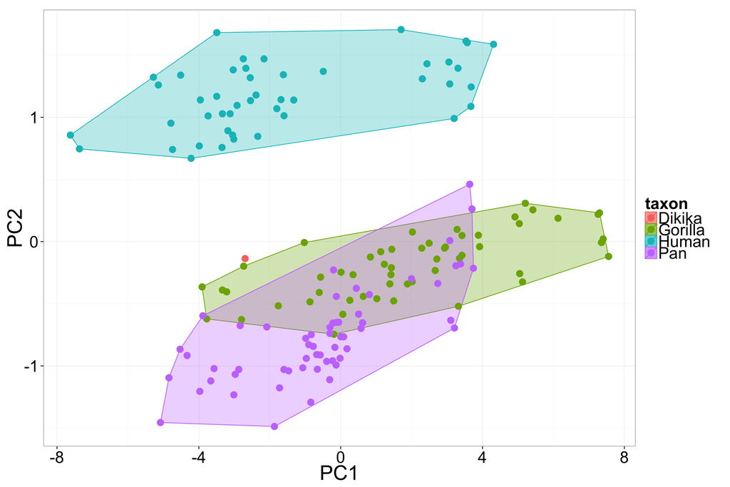

```r
## make taxon variable nicer to look at
taxon <- scap$Taxon
levels(taxon) <- c("Dikika", "Gorilla", "Human", "Pan")

## make a dataframe with just the PC coordinates and taxon
DFforPlot <- data.frame(PC1=PCA$x[,1], PC2=PCA$x[,2], PC3=PCA$x[,3], taxon=taxon)
gorilla <- subset(DFforPlot, taxon=="Gorilla")
pan <- subset(DFforPlot, taxon=="Pan")
human <- subset(DFforPlot, taxon=="Human")


ggplot(aes(x=PC1, y=PC2, color=taxon, fill=taxon), data=DFforPlot) +
  theme_bw(30) +
  geom_polygon(aes(x=PC1, y=PC2), alpha=.3, data=gorilla[chull(gorilla$PC1, gorilla$PC2),]) +
  geom_polygon(aes(x=PC1, y=PC2), alpha=.3, data=pan[chull(pan$PC1, pan$PC2),]) +
  geom_polygon(aes(x=PC1, y=PC2), alpha=.3, data=human[chull(human$PC1, human$PC2),]) +
  geom_point(size=5)
```

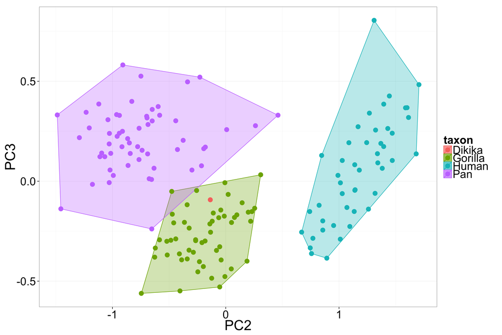

```r
ggplot(aes(x=PC2, y=PC3, color=taxon, fill=taxon), data=DFforPlot) +
  theme_bw(30) +
  geom_polygon(aes(x=PC2, y=PC3), alpha=.3, data=gorilla[chull(gorilla$PC2, gorilla$PC3),]) +
  geom_polygon(aes(x=PC2, y=PC3), alpha=.3, data=pan[chull(pan$PC2, pan$PC3),]) +
  geom_polygon(aes(x=PC2, y=PC3), alpha=.3, data=human[chull(human$PC2, human$PC3),]) +
  geom_point(size=5)
```

### F - 1pt

How do you interpret the first principal component? Justify your interpretation based on the variable loadings.

All of the variables load similarly and positively on the first PC. This is a common situation and reflects the size of the individual. This makes sense, as the most dramatic way that individuals vary from one another is in their size.

## Problem 2

### A - 1pt

load the [dataset from Reed 1997](http://hompal-stats.wabarr.com/datasets/Reed1997_modern_adaptations.csv) with proportions of large mammal adaptations from modern game parks

```r
reed <- read.table("../datasets/Reed1997_modern_adaptations.csv", header=T, sep=",")
```

### B - 1pt

Perform a correspondence analysis on this data

```r
library(ca)
myCA <- ca(reed[,6:12])
```

### C - 1pt

Print the results of the CA

```r
myCA
```

```
##
##  Principal inertias (eigenvalues):
##            1        2       3        4        5        6
## Value      0.206431 0.03197 0.009894 0.005901 0.003697 0.002306
## Percentage 79.34%   12.29%  3.8%     2.27%    1.42%    0.89%
##
##
##  Rows:
##              [,1]      [,2]      [,3]      [,4]      [,5]      [,6]
## Mass     0.034582  0.036865  0.037026  0.030817  0.034827  0.034372
## ChiDist  0.847264  0.825300  0.857517  0.886580  0.625957  0.686674
## Inertia  0.024825  0.025110  0.027226  0.024223  0.013646  0.016207
## Dim. 1  -1.818188 -1.773762 -1.850729 -1.776984 -1.326985 -1.471752
## Dim. 2   0.032219  0.245703 -0.400788 -1.841623  0.803190 -0.250701
##              [,7]      [,8]      [,9]    [,10]    [,11]     [,12]    [,13]
## Mass     0.031891  0.032730  0.032342 0.032288 0.033099  0.031175 0.032531
## ChiDist  0.673616  0.292106  0.212390 0.150979 0.114666  0.177359 0.143278
## Inertia  0.014471  0.002793  0.001459 0.000736 0.000435  0.000981 0.000668
## Dim. 1  -1.385210 -0.516766 -0.206920 0.141110 0.026037  0.290681 0.175380
## Dim. 2  -1.083138  0.619917  0.737329 0.460275 0.285027 -0.590146 0.397535
##            [,14]    [,15]    [,16]     [,17]    [,18]    [,19]    [,20]
## Mass    0.035317 0.032728 0.031806  0.031611 0.030186 0.031325 0.035317
## ChiDist 0.237049 0.263492 0.135932  0.260419 0.261230 0.242086 0.426290
## Inertia 0.001985 0.002272 0.000588  0.002144 0.002060 0.001836 0.006418
## Dim. 1  0.174992 0.347507 0.255379  0.507826 0.456926 0.519671 0.554773
## Dim. 2  0.738801 1.143462 0.074677 -0.203819 0.030972 0.035404 1.838324
##             [,21]     [,22]    [,23]    [,24]     [,25]     [,26]    [,27]
## Mass     0.030173  0.028913 0.032127 0.031752  0.031804  0.027469 0.029382
## ChiDist  0.353485  0.400074 0.375112 0.379041  0.475569  0.561710 0.420385
## Inertia  0.003770  0.004628 0.004521 0.004562  0.007193  0.008667 0.005192
## Dim. 1   0.747150  0.776562 0.737809 0.754714  0.910193  0.989583 0.667235
## Dim. 2  -0.219696 -0.885319 0.788650 0.805256 -0.584196 -1.732604 1.082740
##             [,28]     [,29]    [,30]     [,31]
## Mass     0.030817  0.031737 0.034077  0.028913
## ChiDist  0.880994  0.556227 0.480971  0.587046
## Inertia  0.023919  0.009819 0.007883  0.009964
## Dim. 1   1.544085  1.063014 0.857780  0.885642
## Dim. 2  -2.486743 -0.342006 1.482154 -2.079000
##
##
##  Columns:
##         Arboreality   Aquatic Frugivory Terrestriality  MeatBone
## Mass       0.067097  0.053982  0.131746       0.604336  0.026545
## ChiDist    1.132664  0.517051  0.690466       0.180421  0.877016
## Inertia    0.086081  0.014432  0.062809       0.019672  0.020418
## Dim. 1    -2.449399 -0.327679 -1.493379       0.372747  1.488885
## Dim. 2    -0.639299  2.390068 -0.381426      -0.154106 -2.192970
##         FreshGrass     Grass
## Mass      0.046533  0.069760
## ChiDist   0.633799  0.738981
## Inertia   0.018692  0.038096
## Dim. 1    0.233364  1.478461
## Dim. 2    3.230483 -0.499600
```

### D - 1pt

Make a beautiful ggplot of the results (Dimension 1 plotted against Dimension 2). Hint: You will have to extract the `rowcoords` and `colcoords` from the CA result. Use text labels instead of points. Use the simplified habitat as the label for the localities, rather than the long site name. Color code the labels for each site by the mean annual precipitation values, so you can see the impact of precipitation.

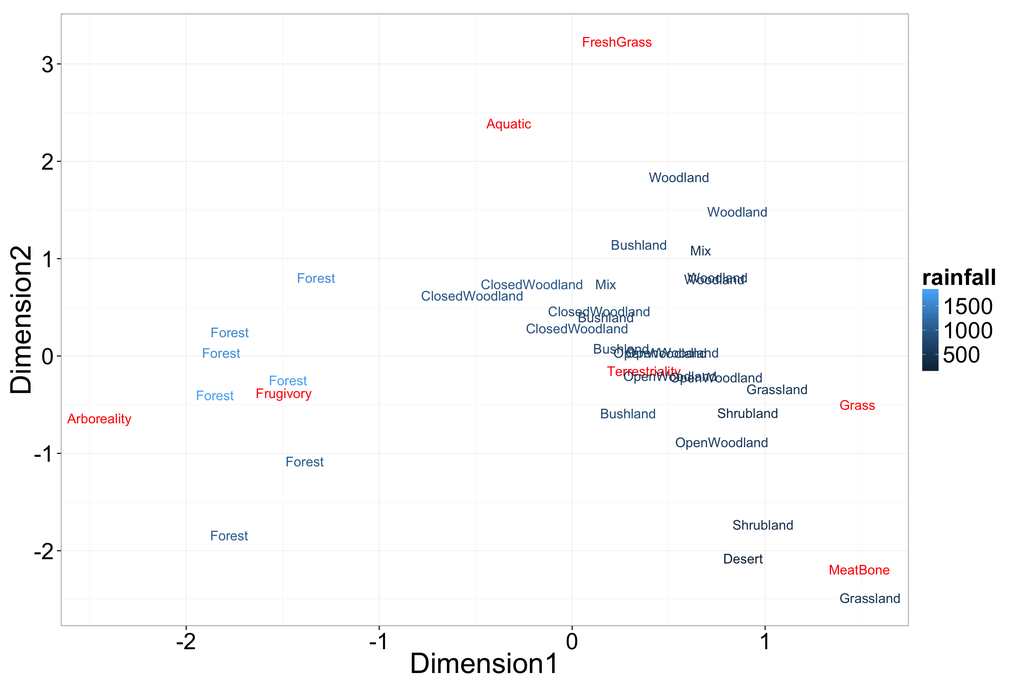

```r
localityScoreDF <- data.frame(Dimension1 = myCA$rowcoord[,1], Dimension2=myCA$rowcoord[,2], rainfall=reed$Rainfall, hab=reed$Simplified.Habitat)
adaptationScoreDF <- data.frame(Dimension1 = myCA$colcoord[,1], Dimension2=myCA$colcoord[,2], names = myCA$colnames)
ggplot() +
  geom_text(aes(x=Dimension1, y=Dimension2, label=names), data=adaptationScoreDF, color="red") +
  geom_text(aes(x=Dimension1, y=Dimension2, label=hab, color=rainfall), data=localityScoreDF)
```